# BCB420 Assignment 1: Dataset Selection and Initial Processing

Kara Han

# Dataset Introduction

GEO Accession Number: GSE166605 Title: RNA-sequencing analysis of effect of miR-155 overexpression in human CD14+ monocytes Summary: This study investigates two groups, miR-155 and negative control, to understand the effect of miR-155 overexpression in human CD14+ monocytes.

# Data Extraction

First, we will extract raw counts data from GEO directly through R.

```r
# The code in this report is adapted from Dr. Ruth Isserlin's Lecture 4-5 slides (Isserlin, 2022).

# Install required packages
if (!require("BiocManager", quietly = TRUE))
    install.packages("BiocManager")

if (!requireNamespace("biomaRt", quietly = TRUE)) {
    BiocManager::install("biomaRt")
}

if (!requireNamespace("GEOquery", quietly = TRUE)) {
    BiocManager::install("GEOquery")
}

if (!requireNamespace("edgeR", quietly = TRUE)) {
    BiocManager::install("edgeR")
}

if (!requireNamespace("limma", quietly = TRUE)) {
    BiocManager::install("limma")
}

if (!require("dplyr", quietly = TRUE)) {
    install.packages("dplyr")
}

# A way to download the dataset only when necessary instead of re-downloading it every time the Notebook is run
gseDirectory <- "/home/rstudio/projects/GSE166605"
if (!file.exists(gseDirectory)) {
  # Get the supplementary files from GEO
  suppFiles <- GEOquery::getGEOSuppFiles("GSE166605")
  # There is only one supplementary file
  fnames <- rownames(suppFiles)
} else {
  fnames <- paste(gseDirectory, "GSE166605_D1-5_Neg_C_miR_155_RAW_counts.txt.gz", sep = "/")
}

# Read in the expression data
expData <- read.delim(fnames[1], header = TRUE, check.names = FALSE)
head(expData)
```

|  | GeneID | Gene name | D1 CD14 Neg C | D1 CD14 miR-155 | D2 CD14 Neg C | D2 CD14 miR-155 | D3 CD14 Neg C | D3 CD14 miR-155 | D4 CD14 Neg C | D4 CD14 miR-155 | D5 CD14 Neg C | D5 CD14 miR-155 |
| --- | --- | --- | --- | --- | --- | --- | --- | --- | --- | --- | --- | --- |
| 1 | ENSG00000223972.5 | DDX11L1 | 0 | 0 | 1 | 0 | 0 | 0 | 0 | 0 | 0 | 0 |
| 2 | ENSG00000227232.5 | WASH7P | 429 | 256 | 152 | 137 | 107 | 129 | 127 | 73 | 140 | 124 |
| 3 | ENSG00000278267.1 | MIR6859-1 | 21 | 26 | 6 | 6 | 13 | 6 | 5 | 7 | 15 | 10 |
| 4 | ENSG00000243485.5 | MIR1302-2HG | 0 | 0 | 0 | 0 | 0 | 0 | 0 | 0 | 0 | 0 |
| 5 | ENSG00000284332.1 | MIR1302-2 | 0 | 0 | 0 | 0 | 0 | 0 | 0 | 0 | 0 | 0 |
| 6 | ENSG00000237613.2 | FAM138A | 0 | 0 | 0 | 0 | 0 | 0 | 0 | 0 | 0 | 0 |

# Cleaning the Data

First, we’ll get an overview of the dataset and check if there are any duplicated genes.

```r
# How many genes do we have measurements for?
dim(expData) # 60603 rows, 12 columns
```

```
## [1] 60603    12
```

```r
length(unique(expData$GeneID)) # 60603
```

```
## [1] 60603
```

```r
colnames(expData)
```

```
##  [1] "GeneID"          "Gene name"       "D1 CD14 Neg C"   "D1 CD14 miR-155"
##  [5] "D2 CD14 Neg C"   "D2 CD14 miR-155" "D3 CD14 Neg C"   "D3 CD14 miR-155"
##  [9] "D4 CD14 Neg C"   "D4 CD14 miR-155" "D5 CD14 Neg C"   "D5 CD14 miR-155"
```

```r
# Compute the overview statistics to assess the quality of your data for both control and test conditions
summary(expData)
```

```
##     GeneID           Gene name         D1 CD14 Neg C      D1 CD14 miR-155
##  Length:60603       Length:60603       Min.   :     0.0   Min.   :     0.0
##  Class :character   Class :character   1st Qu.:     0.0   1st Qu.:     0.0
##  Mode  :character   Mode  :character   Median :     0.0   Median :     0.0
##                                        Mean   :   458.3   Mean   :   432.6
##                                        3rd Qu.:    17.0   3rd Qu.:    13.0
##                                        Max.   :579954.0   Max.   :562318.0
##  D2 CD14 Neg C      D2 CD14 miR-155  D3 CD14 Neg C    D3 CD14 miR-155
##  Min.   :     0.0   Min.   :     0   Min.   :     0   Min.   :     0.0
##  1st Qu.:     0.0   1st Qu.:     0   1st Qu.:     0   1st Qu.:     0.0
##  Median :     0.0   Median :     0   Median :     0   Median :     0.0
##  Mean   :   440.3   Mean   :   417   Mean   :   354   Mean   :   466.3
##  3rd Qu.:    13.0   3rd Qu.:    11   3rd Qu.:     9   3rd Qu.:     9.0
##  Max.   :543539.0   Max.   :524799   Max.   :367168   Max.   :650866.0
##  D4 CD14 Neg C      D4 CD14 miR-155    D5 CD14 Neg C      D5 CD14 miR-155
##  Min.   :     0.0   Min.   :     0.0   Min.   :     0.0   Min.   :     0.0
##  1st Qu.:     0.0   1st Qu.:     0.0   1st Qu.:     0.0   1st Qu.:     0.0
##  Median :     0.0   Median :     0.0   Median :     0.0   Median :     0.0
##  Mean   :   441.4   Mean   :   432.8   Mean   :   471.1   Mean   :   476.4
##  3rd Qu.:    14.0   3rd Qu.:    10.0   3rd Qu.:    12.0   3rd Qu.:    13.5
##  Max.   :311469.0   Max.   :405748.0   Max.   :465564.0   Max.   :549772.0
```

```r
# Are there any expression values that are not unique for specific genes?
dplyr::distinct(expData)
```

| GeneID | Gene name | D1 CD14 Neg C | D1 CD14 miR-155 | D2 CD14 Neg C | D2 CD14 miR-155 | D3 CD14 Neg C | D3 CD14 miR-155 | D4 CD14 Neg C | D4 CD14 miR-155 | D5 CD14 Neg C | D5 CD14 miR-155 |
| --- | --- | --- | --- | --- | --- | --- | --- | --- | --- | --- | --- |
| ENSG00000223972.5 | DDX11L1 | 0 | 0 | 1 | 0 | 0 | 0 | 0 | 0 | 0 | 0 |
| ENSG00000227232.5 | WASH7P | 429 | 256 | 152 | 137 | 107 | 129 | 127 | 73 | 140 | 124 |
| ENSG00000278267.1 | MIR6859-1 | 21 | 26 | 6 | 6 | 13 | 6 | 5 | 7 | 15 | 10 |
| ENSG00000243485.5 | MIR1302-2HG | 0 | 0 | 0 | 0 | 0 | 0 | 0 | 0 | 0 | 0 |
| ENSG00000284332.1 | MIR1302-2 | 0 | 0 | 0 | 0 | 0 | 0 | 0 | 0 | 0 | 0 |
| ENSG00000237613.2 | FAM138A | 0 | 0 | 0 | 0 | 0 | 0 | 0 | 0 | 0 | 0 |
| ENSG00000268020.3 | OR4G4P | 0 | 0 | 0 | 0 | 0 | 0 | 0 | 0 | 0 | 0 |
| ENSG00000240361.2 | OR4G11P | 0 | 0 | 0 | 0 | 0 | 0 | 0 | 0 | 0 | 0 |
| ENSG00000186092.6 | OR4F5 | 0 | 0 | 0 | 0 | 0 | 0 | 0 | 0 | 0 | 0 |
| ENSG00000238009.6 | AL627309.1 | 0 | 4 | 2 | 4 | 1 | 0 | 4 | 1 | 0 | 2 |

[output cut: 9990 more lines]

```r
length(unique(expData$GeneID)) # 60603
```

```
## [1] 60603
```

```r
# Get the summarized counts for each gene
geneCounts <- sort(table(expData$`Gene name`), decreasing = TRUE)
head(geneCounts)
```

```
##
## RF00019 RF00017 RF00012 RF02271 RF00026 RF01210
##     756     170      51      36      33      30
```

We see that there are indeed many duplicated genes including 756 RF00019 and 170 RF00017. The top 3 most duplicated genes in the dataset, RF00019, RF00017, and RF00012, encode for Y RNAs (small non-coding RNA), signal recognition particle RNA, and U3 snoRNA (non-coding RNA), respectively.

## Filter Data

According to the `edgeR` protocol, weakly expressed and non-informative features should be removed. Therefore, our next step involves filtering out genes that have low counts. It is recommended in `edgeR` to remove genes that have less than one read per million (CPM) in n of the samples, where n is the size of the smallest group of replicates. For my dataset, there are 5 samples in each group (miR-155 and negative control), so we set n=5.

```r
# Translate raw counts into counts per million (CPM)
cpms <- edgeR::cpm(expData[, 3:12])
rownames(cpms) <- expData[, 1]

# Keep the genes with high enough counts
keep <- rowSums(cpms > 1) >= 5
expDataFiltered <- expData[keep, ] # 13003 observations

dim(expDataFiltered) # 13003 rows, 12 columns
```

```
## [1] 13003    12
```

```r
length(unique(expDataFiltered$GeneID)) #13003
```

```
## [1] 13003
```

```r
geneCountsFiltered <- sort(table(expDataFiltered$`Gene name`), decreasing = TRUE)
# The duplicate issues have been largely solved
head(geneCountsFiltered)
```

```
##
## RF00019   36951    AHRR  HSPA14 POLR2J3    TBCE
##       3       2       2       2       2       2
```

# Normalization

To choose a suitable normalization method, the first step is to obtain the distribution of the data using a box plot and a density plot.

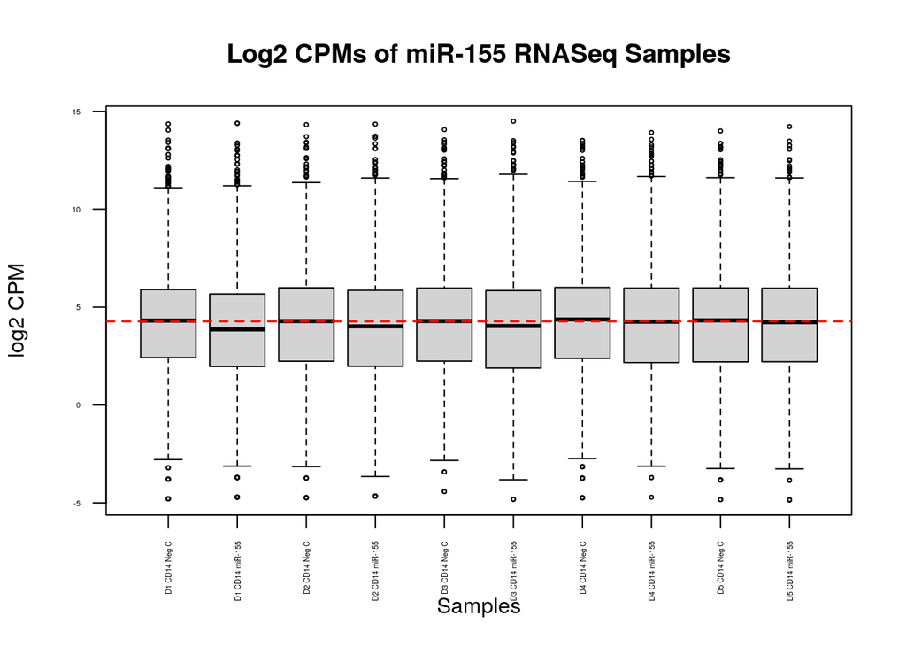

```r
# Calculate the log2 CPM with the filtered data
log2Cpms <- log2(edgeR::cpm(expDataFiltered[, 3:12]))

# A function to draw the box plot
drawBoxPlot <- function(log2Cpms, title) {
  boxplot(log2Cpms, xlab = "Samples", ylab = "log2 CPM",
        las = 2, cex = 0.4, cex.axis = 0.35, main = title)
  # Draw the median line on each box plot
  abline(h = median(apply(log2Cpms, 2, median)), col = "red", lwd = 1.5, lty = "dashed")
}

drawBoxPlot(log2Cpms, title = "Log2 CPMs of miR-155 RNASeq Samples")
```

We obtained some warnings from R console complaining that outliers (-Inf) are not drawn in our box plot. After an examination of the dataframe `log2Cpms`, I found that an outlier is obtained when the gene’s CPM=0 for that sample. Since our criteria is to remove genes without at least 1 read per million in 5 of the samples and we’ve removed those genes, we can ignore the warnings and move on to the next step.

Next, we’ll make a density plot for the log2-CPMs.

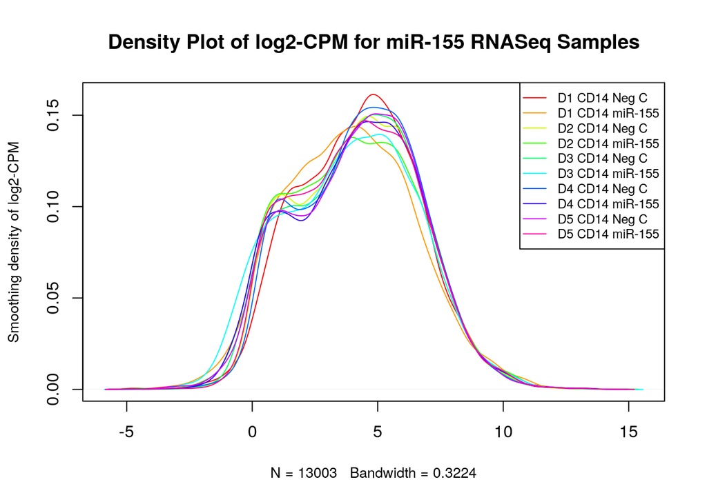

```r
drawDensityPlot <- function(countsData, title, cex) {
  # Calculate the density in each sample
  countsDensity <- apply(log2(edgeR::cpm(countsData)), 2, density)

  # Calculate the limits across all the samples
  xlim <- 0
  ylim <- 0
  for (i in 1:length(countsDensity)) {
    xlim <- range(c(xlim, countsDensity[[i]]$x))
    ylim <- range(c(ylim, countsDensity[[i]]$y))
  }

  # Set the colors and line types for the density plot
  cols <- rainbow(length(countsDensity))
  ltys <- rep(1, length(countsDensity))

  # Initialize the plot
  plot(countsDensity[[1]], xlim = xlim, ylim = ylim, type = "n",
       ylab = "Smoothing density of log2-CPM",
       main = title, cex.lab = 0.85)

  # Plot each line
  for (i in 1:length(countsDensity)) {
    lines(countsDensity[[i]], col = cols[i], lty = ltys[i])
  }

  # Create a legend
  legend("topright", colnames(log2Cpms), col = cols, lty = ltys,
         cex = cex, merge = TRUE)
}
countsData <- expDataFiltered[, 3:12]
drawDensityPlot(countsData,
                title = "Density Plot of log2-CPM for miR-155 RNASeq Samples",
                cex = 0.75)
```

```r
# Make sure the filtered counts is a matrix
filteredDataMatrix <- as.matrix(expDataFiltered[, 3:12])
rownames(filteredDataMatrix) <- expDataFiltered$GeneID
head(filteredDataMatrix)
```

```
##                    D1 CD14 Neg C D1 CD14 miR-155 D2 CD14 Neg C D2 CD14 miR-155
## ENSG00000227232.5            429             256           152             137
## ENSG00000268903.1             93             183            77             107
## ENSG00000269981.1             92             197            89             117
## ENSG00000279457.4            763             516           222             172
## ENSG00000237094.12            75             145            62             104
## ENSG00000225630.1            173             154           141             105
##                    D3 CD14 Neg C D3 CD14 miR-155 D4 CD14 Neg C D4 CD14 miR-155
## ENSG00000227232.5            107             129           127              73
## ENSG00000268903.1             91             119            94              41
## ENSG00000269981.1            101             173           117              48
## ENSG00000279457.4            217             251           280             241
## ENSG00000237094.12            90             137            65              34
## ENSG00000225630.1            224             246           323             252
##                    D5 CD14 Neg C D5 CD14 miR-155
## ENSG00000227232.5            140             124
## ENSG00000268903.1             40              67
## ENSG00000269981.1             34             104
## ENSG00000279457.4            262             239
## ENSG00000237094.12            15              48
## ENSG00000225630.1            373             323
```

```r
# Define the cell types
# Extract the donor and cell types from the original data
samples <- data.frame(lapply(colnames(expData)[3:12],
                             FUN = function(x) {unlist(strsplit(x, split = " "))[c(1, 3)]}))
colnames(samples) <- colnames(expData)[3:12]
rownames(samples) <- c("donors", "cell_type")
samples <- data.frame(t(samples))

# Create a DGEList object
d <- edgeR::DGEList(counts = filteredDataMatrix, group = samples$cell_type)
# Calculate the normalization factors
dgeObj <- edgeR::calcNormFactors(d, method = "TMM")

# What are the normalized counts?
normalizedCounts <- edgeR::cpm(dgeObj)
head(normalizedCounts)
```

```
##                    D1 CD14 Neg C D1 CD14 miR-155 D2 CD14 Neg C D2 CD14 miR-155
## ENSG00000227232.5      13.903184       11.574913      5.413342        5.927910
## ENSG00000268903.1       3.013977        8.274254      2.742285        4.629827
## ENSG00000269981.1       2.981569        8.907257      3.169654        5.062521
## ENSG00000279457.4      24.727575       23.330684      7.906328        7.442339
## ENSG00000237094.12      2.430627        6.556103      2.208074        4.500019
## ENSG00000225630.1       5.606645        6.963034      5.021587        4.543288
##                    D3 CD14 Neg C D3 CD14 miR-155 D4 CD14 Neg C D4 CD14 miR-155
## ENSG00000227232.5       4.794842        5.153435      4.325561        2.786859
## ENSG00000268903.1       4.077857        4.753944      3.201596        1.565222
## ENSG00000269981.1       4.525973        6.911196      3.984965        1.832456
## ENSG00000279457.4       9.724120       10.027226      9.536670        9.200454
## ENSG00000237094.12      4.033045        5.473028      2.213870        1.297989
## ENSG00000225630.1      10.037801        9.827480     11.001229        9.620392
##                    D5 CD14 Neg C D5 CD14 miR-155
## ENSG00000227232.5      4.6515675        4.273434
## ENSG00000268903.1      1.3290193        2.309033
## ENSG00000269981.1      1.1296664        3.584170
## ENSG00000279457.4      8.7050763        8.236699
## ENSG00000237094.12     0.4983822        1.654232
## ENSG00000225630.1     12.3931048       11.131606
```

```r
summary(normalizedCounts)
```

```
##  D1 CD14 Neg C       D1 CD14 miR-155     D2 CD14 Neg C
##  Min.   :    0.000   Min.   :    0.000   Min.   :    0.000
##  1st Qu.:    4.796   1st Qu.:    4.612   1st Qu.:    4.452
##  Median :   17.792   Median :   17.136   Median :   18.484
##  Mean   :   68.897   Mean   :   90.762   Mean   :   72.802
##  3rd Qu.:   53.441   3rd Qu.:   60.045   3rd Qu.:   60.045
##  Max.   :18795.355   Max.   :25424.929   Max.   :19357.646
##  D2 CD14 miR-155     D3 CD14 Neg C       D3 CD14 miR-155
##  Min.   :    0.000   Min.   :    0.000   Min.   :    0.000
##  1st Qu.:    4.284   1st Qu.:    4.526   1st Qu.:    4.155
##  Median :   17.654   Median :   18.731   Median :   18.496
##  Mean   :   83.771   Mean   :   73.708   Mean   :   86.610
##  3rd Qu.:   63.346   3rd Qu.:   60.160   3rd Qu.:   64.738
##  Max.   :22707.745   Max.   :16453.390   Max.   :26001.516
##  D4 CD14 Neg C       D4 CD14 miR-155     D5 CD14 Neg C
##  Min.   :    0.000   Min.   :    0.000   Min.   :    0.000
##  1st Qu.:    4.734   1st Qu.:    4.486   1st Qu.:    4.353
##  Median :   18.801   Median :   19.088   Median :   18.939
##  Mean   :   69.816   Mean   :   76.805   Mean   :   72.706
##  3rd Qu.:   58.310   3rd Qu.:   62.685   3rd Qu.:   59.656
##  Max.   :10608.489   Max.   :15489.899   Max.   :15468.588
##  D5 CD14 miR-155
##  Min.   :    0.000
##  1st Qu.:    4.584
##  Median :   18.610
##  Mean   :   76.247
##  3rd Qu.:   61.999
##  Max.   :18946.889
```

## Exploratory Data Analysis

Let’s compare the box plot and density plot before and after normalization to demonstrate the effect of normalization on our data.

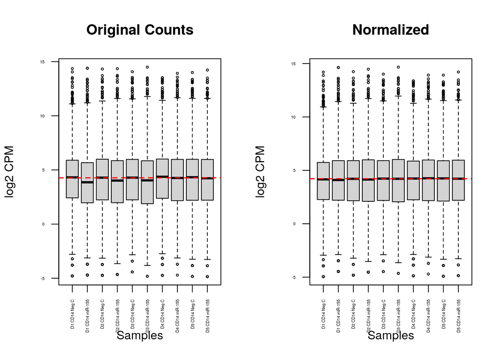

```r
# Compare the box plots
par(mfrow = c(1, 2))
drawBoxPlot(log2Cpms, title = "Original Counts")
drawBoxPlot(log2(normalizedCounts), title = "Normalized")
```

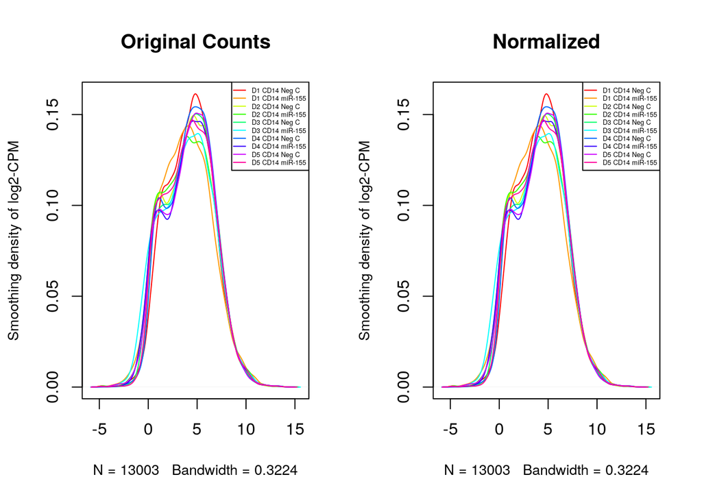

```r
par(mfrow = c(1, 2))
countsData <- expDataFiltered[, 3:12]
drawDensityPlot(countsData, title = "Original Counts", cex = 0.4)
drawDensityPlot(normalizedCounts, title = "Normalized", cex = 0.4)
```

Even though the density plots almost look the same before and after normalization, we do see the effect of normalization through the comparison of the box plots: the medians of each sample are adjusted and now fit the median line better. For both box and density plots, the post-normalization plot distributes in the same intervals with the same density center as the pre-normalization plot, suggesting correct use of normalization in this case.

We’ll also use a multidimensional scaling (MDS) plot to represent the distances between samples post normalization.

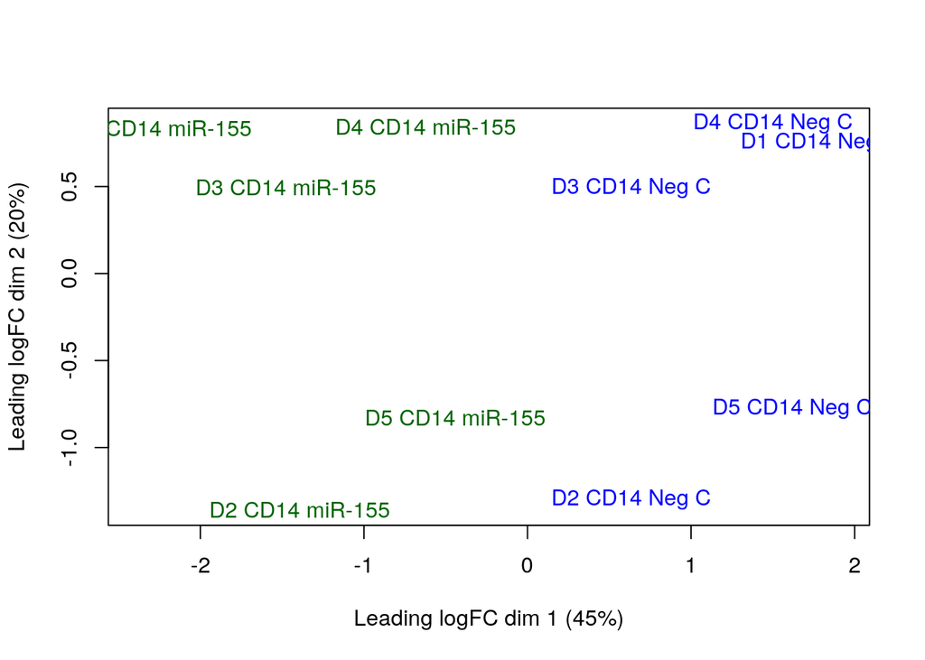

```r
limma::plotMDS(d, labels = rownames(samples), col = c("darkgreen", "blue")[factor(samples$cell_type)])
```

Notice that the two groups of the samples are clearly separated, suggesting that miR-155 groups and negative control groups indeed have different behaviors across their counts and differential expressions.

Next, we’ll use `edgeR` to calculate the dispersion, which measures how much variation there is in our samples.

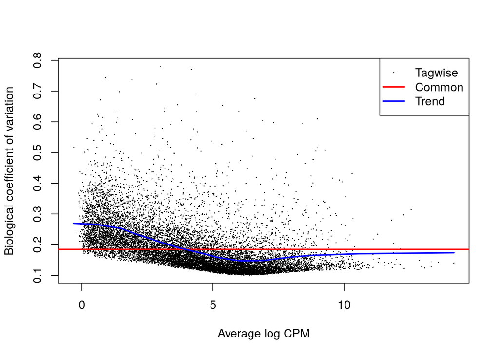

```r
# Calculate the dispersion
modelMatrix <- model.matrix(~samples$donors + samples$cell_type+0)
dispersion <- edgeR::estimateDisp(d, modelMatrix)

# Plot the biological coefficient of variation (BCV)
edgeR::plotBCV(dispersion, col.tagwise = "black", col.common = "red")
```

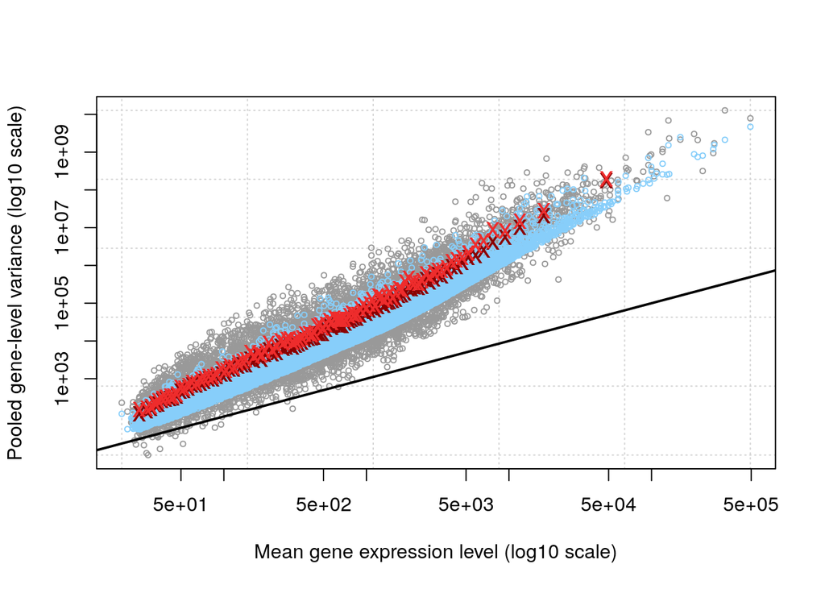

```r
# Plot the mean-variance relationship
edgeR::plotMeanVar(dispersion,
                   show.raw.vars = TRUE,
                   show.tagwise.vars = TRUE,
                   NBline = FALSE,
                   show.ave.raw.vars = TRUE,
                   show.binned.common.disp.vars = TRUE)
```

# Identifier Mapping

In this final step, we’ll map the ensembl gene IDs to HGNC symbols in our dataset.

```r
# Load the biomaRt library and choose the Mart and Dataset to use
library(biomaRt)

# The line below is run to avoid Error in curl::curl_fetch_memory(url, handle = handle)
# when running the useMart function
httr::set_config(httr::config(ssl_verifypeer = 0L))
ensembl <- useMart("ensembl")
hsapiens <- useDataset("hsapiens_gene_ensembl", mart = ensembl)

# Before the conversion, we'll remove the version numbers after "." in the
# ensembl gene ID column in our original dataset for use in biomaRt
newExpDataFiltered <- expDataFiltered
newExpDataFiltered$GeneID <- gsub("\\..*", "", newExpDataFiltered$GeneID)

# Convert the ensembl gene IDs to HGNC symbols
conversions <- getBM(attributes = c("ensembl_gene_id", "hgnc_symbol"),
                     filters = c("ensembl_gene_id"),
                     values = newExpDataFiltered$GeneID,
                     mart = hsapiens)
```

Let’s evaluate this conversion.

```r
# We were able to map 12978 genes
length(which(gsub("\\..*", "", rownames(normalizedCounts)) %in% conversions$ensembl_gene_id))
```

```
## [1] 12978
```

```r
# Out of 13003 genes that we started with
nrow(normalizedCounts)
```

```
## [1] 13003
```

```r
# The difference is 25 genes
nrow(normalizedCounts) - length(which(gsub("\\..*", "", rownames(normalizedCounts)) %in% conversions$ensembl_gene_id))
```

```
## [1] 25
```

```r
# Merging the new identifiers
rownames(normalizedCounts) <- gsub("\\..*", "", rownames(normalizedCounts))
normalizedCountsHGNC <- merge(conversions, normalizedCounts,
                              by.x = 'ensembl_gene_id',
                              by.y = 'row.names',
                              all.y = TRUE)

# Getting an overview of the new dataset
nrow(normalizedCountsHGNC) # 13004
```

```
## [1] 13004
```

```r
length(unique(normalizedCountsHGNC$ensembl_gene_id)) #13003
```

```
## [1] 13003
```

We see that merging the two datasets resulted in a total of 13004 rows, but there are only 13003 unique Ensembl gene IDs. This means that two rows have the same Ensembl gene ID. Let’s find out which rows those are.

```r
# The code below is adapted from https://stackoverflow.com/questions/16905425/find-duplicate-values-in-r.
n_occur <- data.frame(table(normalizedCountsHGNC$ensembl_gene_id))
normalizedCountsHGNC[normalizedCountsHGNC$ensembl_gene_id %in% n_occur$Var1[n_occur$Freq > 1],]
```

|  | ensembl_gene_id | hgnc_symbol | D1 CD14 Neg C | D1 CD14 miR-155 | D2 CD14 Neg C | D2 CD14 miR-155 | D3 CD14 Neg C | D3 CD14 miR-155 | D4 CD14 Neg C | D4 CD14 miR-155 | D5 CD14 Neg C | D5 CD14 miR-155 |
| --- | --- | --- | --- | --- | --- | --- | --- | --- | --- | --- | --- | --- |
| 12595 | ENSG00000276085 | CCL3L3 | 9.236381 | 41.55213 | 45.22989 | 77.49552 | 5.332582 | 13.74249 | 13.69193 | 8.322402 | 7.974116 | 7.547436 |
| 12596 | ENSG00000276085 | CCL3L1 | 9.236381 | 41.55213 | 45.22989 | 77.49552 | 5.332582 | 13.74249 | 13.69193 | 8.322402 | 7.974116 | 7.547436 |

```r
# The same Ensembl gene ID mapped to different HGNC symbols - and the counts are
# the same for the two rows, which introduces repeating information.e\
# Let's go back to normalizedCounts and check whether ENSG00000276085 is also repeated
normalizedCounts[gsub("\\..*", "", rownames(normalizedCounts)) == "ENSG00000276085", ]
```

```
##   D1 CD14 Neg C D1 CD14 miR-155   D2 CD14 Neg C D2 CD14 miR-155   D3 CD14 Neg C
##        9.236381       41.552129       45.229893       77.495520        5.332582
## D3 CD14 miR-155   D4 CD14 Neg C D4 CD14 miR-155   D5 CD14 Neg C D5 CD14 miR-155
##       13.742493       13.691933        8.322402        7.974116        7.547436
```

It only resulted in one row, which means that there is only one row containing the Ensembl ID ENSG00000276085 in the original dataset.

Now is a good idea to do a manual verification for the two HGNC symbols: CCL3L3 and CCL3L1. CCL3L3 has ID ENSG00000276085.1, while CCL3L1 has ID ENSG00000277336.2. It seems like there might be a slight problem with mapping the gene symbols, possibly an Ensembl version update issue.

We have ENSG00000276085.1 in our original dataset, so I’ve decided to remove the row containing CCL3L1 from the normalizedCountsHGNC.

```r
# Remove the row containing CCL3L1 from normalizedCountsHGNC
normalizedCountsHGNC <- normalizedCountsHGNC[-c(12596), ]
# Now there is only one row left with Ensembl ID ENSG00000276085
normalizedCountsHGNC[normalizedCountsHGNC$ensembl_gene_id == "ENSG00000276085", ]
```

|  | ensembl_gene_id | hgnc_symbol | D1 CD14 Neg C | D1 CD14 miR-155 | D2 CD14 Neg C | D2 CD14 miR-155 | D3 CD14 Neg C | D3 CD14 miR-155 | D4 CD14 Neg C | D4 CD14 miR-155 | D5 CD14 Neg C | D5 CD14 miR-155 |
| --- | --- | --- | --- | --- | --- | --- | --- | --- | --- | --- | --- | --- |
| 12595 | ENSG00000276085 | CCL3L3 | 9.236381 | 41.55213 | 45.22989 | 77.49552 | 5.332582 | 13.74249 | 13.69193 | 8.322402 | 7.974116 | 7.547436 |

```r
# Change the row names to the Ensembl gene IDs
rownames(normalizedCountsHGNC) <- normalizedCountsHGNC$ensembl_gene_id
```

Next, let’s figure out how many genes are missing HGNC symbols.

```r
# How many identifiers are missing?
ensemblMissingGenes <- normalizedCountsHGNC$ensembl_gene_id[which(is.na(normalizedCountsHGNC$hgnc_symbol))]

# There are 25 genes missing HGNC symbols
length(ensemblMissingGenes)
```

```
## [1] 25
```

```r
# which is ~0.1% of our dataset
25 / 13003
```

```
## [1] 0.001922633
```

```r
ensemblMissingGenesDF <- data.frame(GeneID = ensemblMissingGenes)
oldMapping <- merge(newExpDataFiltered[, 1:2], ensemblMissingGenesDF,
                    by = 'GeneID')
nrow(oldMapping)
```

```
## [1] 25
```

```r
head(oldMapping)
```

|  | GeneID | Gene name |
| --- | --- | --- |
| 1 | ENSG00000116883 | AL591845.1 |
| 2 | ENSG00000130723 | PRRC2B |
| 3 | ENSG00000182584 | ACTL10 |
| 4 | ENSG00000204282 | TNRC6C-AS1 |
| 5 | ENSG00000225178 | RPSAP58 |
| 6 | ENSG00000228106 | AL392172.1 |

# Interpretation

1. What are the control and test conditions of the dataset?

The test condition is CD14+ monocytes transfected with miR-155. The control condition is CD14+ monocytes transfected with negative control mimic.

2. Why is the dataset of interest to you?

I’m fascinated by the disease mechanisms of autoimmune diseases - your immune system attacks healthy cells by mistake and causes inflammation. And this dataset studies the role of miR-155 that is implicated in rheumatoid arthritis (RA, an autoimmune disease), which is a very painful disease that causes many inconveniences and can damage other body systems.

3. Were there expression values that were not unique for specific genes? How did you handle these?

All expression values and Ensembl IDs were unique for specific genes in the original dataset.

4. Were there expression values that could not be mapped to current HUGO symbols?

5. How many outliers were removed?

No significant outliers were found so none were removed.

6. How did you handle replicates?

The samples came from 5 different donors, which are noise sources. To handle replicates, I first extracted the donors and cell types from the original dataset to get a clear picture of what the samples are. Then, I applied normalization to take care of technical variations. Finally, genes with low counts in more than 5 samples removed to ensure the quality of the data.

7. What is the final coverage of your dataset?

The final coverage of my dataset is 13003 genes with their Ensembl gene IDs, HGNC symbols, and normalized counts in 10 samples.

# References

Isserlin, R. (2022). Lecture 4 - Data Exploration and Normalization. Quercus. https://q.utoronto.ca/courses/248455/files/19273570?module_item_id=3476594

Isserlin, R. (2022). Lecture 5 - Data Exploration and Identifier Mapping. Quercus. https://q.utoronto.ca/courses/248455/files/18120883?module_item_id=3463354

Kikapp. (2013). Find duplicate values in R. https://stackoverflow.com/questions/16905425/find-duplicate-values-in-r.